# Assignment 5

Fabrizio Fiorini

4/25/2021

## HIERARCHICAL CLUSTERING ANALYSIS

# Loading packages and data exploration

The dataset we are going to use contains information on 77 different breakfast cereals. Some of the variables refer to nutritional information, store display, consumer rating, manufacturer, physical values like weight and number of cups.

First, let us load the required libraries and import the “cereal.csv” dataset.

```r
#loading the libraries
library(cluster)
library(factoextra)
library(caret)
#importing the dataset
cereals.df <- read.csv("Cereals.csv")
```

```r
#exploring data
head(cereals.df)
```

```
##                        name mfr type calories protein fat sodium fiber carbo
## 1                 100%_Bran   N    C       70       4   1    130  10.0   5.0
## 2         100%_Natural_Bran   Q    C      120       3   5     15   2.0   8.0
## 3                  All-Bran   K    C       70       4   1    260   9.0   7.0
## 4 All-Bran_with_Extra_Fiber   K    C       50       4   0    140  14.0   8.0
## 5            Almond_Delight   R    C      110       2   2    200   1.0  14.0
## 6   Apple_Cinnamon_Cheerios   G    C      110       2   2    180   1.5  10.5
##   sugars potass vitamins shelf weight cups   rating
## 1      6    280       25     3      1 0.33 68.40297
## 2      8    135        0     3      1 1.00 33.98368
## 3      5    320       25     3      1 0.33 59.42551
## 4      0    330       25     3      1 0.50 93.70491
## 5      8     NA       25     3      1 0.75 34.38484
## 6     10     70       25     1      1 0.75 29.50954
```

```r
str(cereals.df)
```

```
## 'data.frame':    77 obs. of  16 variables:
##  $ name    : chr  "100%_Bran" "100%_Natural_Bran" "All-Bran" "All-Bran_with_Extra_Fiber" ...
##  $ mfr     : chr  "N" "Q" "K" "K" ...
##  $ type    : chr  "C" "C" "C" "C" ...
##  $ calories: int  70 120 70 50 110 110 110 130 90 90 ...
##  $ protein : int  4 3 4 4 2 2 2 3 2 3 ...
##  $ fat     : int  1 5 1 0 2 2 0 2 1 0 ...
##  $ sodium  : int  130 15 260 140 200 180 125 210 200 210 ...
##  $ fiber   : num  10 2 9 14 1 1.5 1 2 4 5 ...
##  $ carbo   : num  5 8 7 8 14 10.5 11 18 15 13 ...
##  $ sugars  : int  6 8 5 0 8 10 14 8 6 5 ...
##  $ potass  : int  280 135 320 330 NA 70 30 100 125 190 ...
##  $ vitamins: int  25 0 25 25 25 25 25 25 25 25 ...
##  $ shelf   : int  3 3 3 3 3 1 2 3 1 3 ...
##  $ weight  : num  1 1 1 1 1 1 1 1.33 1 1 ...
##  $ cups    : num  0.33 1 0.33 0.5 0.75 0.75 1 0.75 0.67 0.67 ...
##  $ rating  : num  68.4 34 59.4 93.7 34.4 ...
```

```r
summary(cereals.df)
```

```
##      name               mfr                type              calories
##  Length:77          Length:77          Length:77          Min.   : 50.0
##  Class :character   Class :character   Class :character   1st Qu.:100.0
##  Mode  :character   Mode  :character   Mode  :character   Median :110.0
##                                                           Mean   :106.9
##                                                           3rd Qu.:110.0
##                                                           Max.   :160.0
##
##     protein           fat            sodium          fiber
##  Min.   :1.000   Min.   :0.000   Min.   :  0.0   Min.   : 0.000
##  1st Qu.:2.000   1st Qu.:0.000   1st Qu.:130.0   1st Qu.: 1.000
##  Median :3.000   Median :1.000   Median :180.0   Median : 2.000
##  Mean   :2.545   Mean   :1.013   Mean   :159.7   Mean   : 2.152
##  3rd Qu.:3.000   3rd Qu.:2.000   3rd Qu.:210.0   3rd Qu.: 3.000
##  Max.   :6.000   Max.   :5.000   Max.   :320.0   Max.   :14.000
##
##      carbo          sugars           potass          vitamins
##  Min.   : 5.0   Min.   : 0.000   Min.   : 15.00   Min.   :  0.00
##  1st Qu.:12.0   1st Qu.: 3.000   1st Qu.: 42.50   1st Qu.: 25.00
##  Median :14.5   Median : 7.000   Median : 90.00   Median : 25.00
##  Mean   :14.8   Mean   : 7.026   Mean   : 98.67   Mean   : 28.25
##  3rd Qu.:17.0   3rd Qu.:11.000   3rd Qu.:120.00   3rd Qu.: 25.00
##  Max.   :23.0   Max.   :15.000   Max.   :330.00   Max.   :100.00
##  NA's   :1      NA's   :1        NA's   :2
##      shelf           weight          cups           rating
##  Min.   :1.000   Min.   :0.50   Min.   :0.250   Min.   :18.04
##  1st Qu.:1.000   1st Qu.:1.00   1st Qu.:0.670   1st Qu.:33.17
##  Median :2.000   Median :1.00   Median :0.750   Median :40.40
##  Mean   :2.208   Mean   :1.03   Mean   :0.821   Mean   :42.67
##  3rd Qu.:3.000   3rd Qu.:1.00   3rd Qu.:1.000   3rd Qu.:50.83
##  Max.   :3.000   Max.   :1.50   Max.   :1.500   Max.   :93.70
##
```

```r
dim(cereals.df)
```

```
## [1] 77 16
```

From the exploration activity done above, we know that the first 3 variables (name, mfr, type) are categorical, therefore we need to transform them in dummy variables or, in the case of the first column, use it as names for the rows. The other 13 variables are quantitative. There are also some missing values that we have to deal with and, if possible, remove on the following variables: carbo, sugar, potassium. Zooming out, we realized that the dataset is formed by 77 observations and 16 variables.

```r
#removing null values
colMeans(is.na(cereals.df))
```

```
##       name        mfr       type   calories    protein        fat     sodium
## 0.00000000 0.00000000 0.00000000 0.00000000 0.00000000 0.00000000 0.00000000
##      fiber      carbo     sugars     potass   vitamins      shelf     weight
## 0.00000000 0.01298701 0.01298701 0.02597403 0.00000000 0.00000000 0.00000000
##       cups     rating
## 0.00000000 0.00000000
```

```r
cereals.df <- cereals.df[complete.cases(cereals.df),]
colMeans(is.na(cereals.df))
```

```
##     name      mfr     type calories  protein      fat   sodium    fiber
##        0        0        0        0        0        0        0        0
##    carbo   sugars   potass vitamins    shelf   weight     cups   rating
##        0        0        0        0        0        0        0        0
```

```r
#exploring data with no null values
head(cereals.df)
```

```
##                        name mfr type calories protein fat sodium fiber carbo
## 1                 100%_Bran   N    C       70       4   1    130  10.0   5.0
## 2         100%_Natural_Bran   Q    C      120       3   5     15   2.0   8.0
## 3                  All-Bran   K    C       70       4   1    260   9.0   7.0
## 4 All-Bran_with_Extra_Fiber   K    C       50       4   0    140  14.0   8.0
## 6   Apple_Cinnamon_Cheerios   G    C      110       2   2    180   1.5  10.5
## 7               Apple_Jacks   K    C      110       2   0    125   1.0  11.0
##   sugars potass vitamins shelf weight cups   rating
## 1      6    280       25     3      1 0.33 68.40297
## 2      8    135        0     3      1 1.00 33.98368
## 3      5    320       25     3      1 0.33 59.42551
## 4      0    330       25     3      1 0.50 93.70491
## 6     10     70       25     1      1 0.75 29.50954
## 7     14     30       25     2      1 1.00 33.17409
```

```r
summary(cereals.df)
```

```
##      name               mfr                type              calories
##  Length:74          Length:74          Length:74          Min.   : 50
##  Class :character   Class :character   Class :character   1st Qu.:100
##  Mode  :character   Mode  :character   Mode  :character   Median :110
##                                                           Mean   :107
##                                                           3rd Qu.:110
##                                                           Max.   :160
##     protein           fat        sodium          fiber            carbo
##  Min.   :1.000   Min.   :0   Min.   :  0.0   Min.   : 0.000   Min.   : 5.00
##  1st Qu.:2.000   1st Qu.:0   1st Qu.:135.0   1st Qu.: 0.250   1st Qu.:12.00
##  Median :2.500   Median :1   Median :180.0   Median : 2.000   Median :14.50
##  Mean   :2.514   Mean   :1   Mean   :162.4   Mean   : 2.176   Mean   :14.73
##  3rd Qu.:3.000   3rd Qu.:1   3rd Qu.:217.5   3rd Qu.: 3.000   3rd Qu.:17.00
##  Max.   :6.000   Max.   :5   Max.   :320.0   Max.   :14.000   Max.   :23.00
##      sugars           potass          vitamins          shelf
##  Min.   : 0.000   Min.   : 15.00   Min.   :  0.00   Min.   :1.000
##  1st Qu.: 3.000   1st Qu.: 41.25   1st Qu.: 25.00   1st Qu.:1.250
##  Median : 7.000   Median : 90.00   Median : 25.00   Median :2.000
##  Mean   : 7.108   Mean   : 98.51   Mean   : 29.05   Mean   :2.216
##  3rd Qu.:11.000   3rd Qu.:120.00   3rd Qu.: 25.00   3rd Qu.:3.000
##  Max.   :15.000   Max.   :330.00   Max.   :100.00   Max.   :3.000
##      weight           cups            rating
##  Min.   :0.500   Min.   :0.2500   Min.   :18.04
##  1st Qu.:1.000   1st Qu.:0.6700   1st Qu.:32.45
##  Median :1.000   Median :0.7500   Median :40.25
##  Mean   :1.031   Mean   :0.8216   Mean   :42.37
##  3rd Qu.:1.000   3rd Qu.:1.0000   3rd Qu.:50.52
##  Max.   :1.500   Max.   :1.5000   Max.   :93.70
```

```r
#assigning names to the rows
cereals.short <- cereals.df
row.names(cereals.short) <- cereals.short[,1]
cereals.short <- cereals.short[,-c(1:3)]
dim(cereals.short)
```

```
## [1] 74 13
```

After we removed the null values, the dataset contains 74 observations. Therefore, we can say that we only lost 4% of the data. We also used the first variable, the one that tells us the cereals name, as row name. Then, we removed the 3 categorical variables from our dataset because our main focus here is on the nutritional components. Now the dataset has 74 observations and 13 variables.

# Data normalization

Since we are dealing with variables of very different nature that are expressed in different units, we have to normalized the data before applying any algorithm.

```r
#normalizing data
cereals.norm <- scale(cereals.short)
head(cereals.norm)
```

```
##                             calories    protein        fat     sodium
## 100%_Bran                 -1.8659155  1.3817478  0.0000000 -0.3910227
## 100%_Natural_Bran          0.6537514  0.4522084  3.9728810 -1.7804186
## All-Bran                  -1.8659155  1.3817478  0.0000000  1.1795987
## All-Bran_with_Extra_Fiber -2.8737823  1.3817478 -0.9932203 -0.2702057
## Apple_Cinnamon_Cheerios    0.1498180 -0.4773310  0.9932203  0.2130625
## Apple_Jacks                0.1498180 -0.4773310 -0.9932203 -0.4514312
##                                 fiber      carbo     sugars     potass
## 100%_Bran                  3.22866747 -2.5001396 -0.2542051  2.5605229
## 100%_Natural_Bran         -0.07249167 -1.7292632  0.2046041  0.5147738
## All-Bran                   2.81602258 -1.9862220 -0.4836096  3.1248675
## All-Bran_with_Extra_Fiber  4.87924705 -1.7292632 -1.6306324  3.2659536
## Apple_Cinnamon_Cheerios   -0.27881412 -1.0868662  0.6634132 -0.4022862
## Apple_Jacks               -0.48513656 -0.9583868  1.5810314 -0.9666308
##                             vitamins      shelf     weight       cups
## 100%_Bran                 -0.1818422  0.9419715 -0.2008324 -2.0856582
## 100%_Natural_Bran         -1.3032024  0.9419715 -0.2008324  0.7567534
## All-Bran                  -0.1818422  0.9419715 -0.2008324 -2.0856582
## All-Bran_with_Extra_Fiber -0.1818422  0.9419715 -0.2008324 -1.3644493
## Apple_Cinnamon_Cheerios   -0.1818422 -1.4616799 -0.2008324 -0.3038480
## Apple_Jacks               -0.1818422 -0.2598542 -0.2008324  0.7567534
##                               rating
## 100%_Bran                  1.8549038
## 100%_Natural_Bran         -0.5977113
## All-Bran                   1.2151965
## All-Bran_with_Extra_Fiber  3.6578436
## Apple_Cinnamon_Cheerios   -0.9165248
## Apple_Jacks               -0.6553998
```

```r
summary(cereals.norm)
```

```
##     calories          protein              fat              sodium
##  Min.   :-2.8738   Min.   :-1.40687   Min.   :-0.9932   Min.   :-1.9616
##  1st Qu.:-0.3541   1st Qu.:-0.47733   1st Qu.:-0.9932   1st Qu.:-0.3306
##  Median : 0.1498   Median :-0.01256   Median : 0.0000   Median : 0.2131
##  Mean   : 0.0000   Mean   : 0.00000   Mean   : 0.0000   Mean   : 0.0000
##  3rd Qu.: 0.1498   3rd Qu.: 0.45221   3rd Qu.: 0.0000   3rd Qu.: 0.6661
##  Max.   : 2.6695   Max.   : 3.24083   Max.   : 3.9729   Max.   : 1.9045
##      fiber              carbo              sugars            potass
##  Min.   :-0.89778   Min.   :-2.50014   Min.   :-1.6306   Min.   :-1.1783
##  1st Qu.:-0.79462   1st Qu.:-0.70143   1st Qu.:-0.9424   1st Qu.:-0.8079
##  Median :-0.07249   Median :-0.05903   Median :-0.0248   Median :-0.1201
##  Mean   : 0.00000   Mean   : 0.00000   Mean   : 0.0000   Mean   : 0.0000
##  3rd Qu.: 0.34015   3rd Qu.: 0.58337   3rd Qu.: 0.8928   3rd Qu.: 0.3031
##  Max.   : 4.87925   Max.   : 2.12512   Max.   : 1.8104   Max.   : 3.2660
##     vitamins           shelf             weight             cups
##  Min.   :-1.3032   Min.   :-1.4617   Min.   :-3.4600   Min.   :-2.4251
##  1st Qu.:-0.1818   1st Qu.:-1.1612   1st Qu.:-0.2008   1st Qu.:-0.6432
##  Median :-0.1818   Median :-0.2599   Median :-0.2008   Median :-0.3038
##  Mean   : 0.0000   Mean   : 0.0000   Mean   : 0.0000   Mean   : 0.0000
##  3rd Qu.:-0.1818   3rd Qu.: 0.9420   3rd Qu.:-0.2008   3rd Qu.: 0.7568
##  Max.   : 3.1822   Max.   : 0.9420   Max.   : 3.0583   Max.   : 2.8780
##      rating
##  Min.   :-1.7336
##  1st Qu.:-0.7071
##  Median :-0.1510
##  Mean   : 0.0000
##  3rd Qu.: 0.5807
##  Max.   : 3.6578
```

# Clustering Analysis

Clustering is an unsupervised machine learning technique used to group data according to their similarities. There are 2 main apporach to clustering analysis: Divisive (top-bottom, or DIANA) and Agglomerative (bottom-up, AGNES). In this case, we are going to apply the agnes() function from the “cluster” package. This function has been preferred to the hclust() function because it gives us a numerical measure of the strength of the cluster structure, called agglomerative coefficient. This metric allow us to compare the goodness of the different linkage we used: single, complete, average and ward’s method.

```r
set.seed(123)

#running AGNES for different linkages
hc_s <- agnes(cereals.norm, method = "single")
hc_c <- agnes(cereals.norm, method = "complete")
hc_a <- agnes(cereals.norm, method = "average")
hc_w <- agnes(cereals.norm, method = "ward")

#comparing agglomerative coefficients
print(hc_s$ac)
```

```
## [1] 0.6067859
```

```r
print(hc_c$ac)
```

```
## [1] 0.8353712
```

```r
print(hc_a$ac)
```

```
## [1] 0.7766075
```

```r
print(hc_w$ac)
```

```
## [1] 0.9046042
```

From the results we can conclude that the best method is the Ward’s method, which gives a coefficient of 90.46%. Ward’s method aims to minimize the total within-cluster variance. It considers the “loss of information” that occurs when records are clustered together. When records are joined together and represented in clusters, information about an individual record is replaced by the information of the cluster. To measure loss of information, Ward’s method employs the “error sum of squares” (ESS) that measures the difference between individual records and a group mean.

Usually, when dealing with hierchical clustering, a dendrogram is used to visually show the progressive grouping of data points and the distance between them.

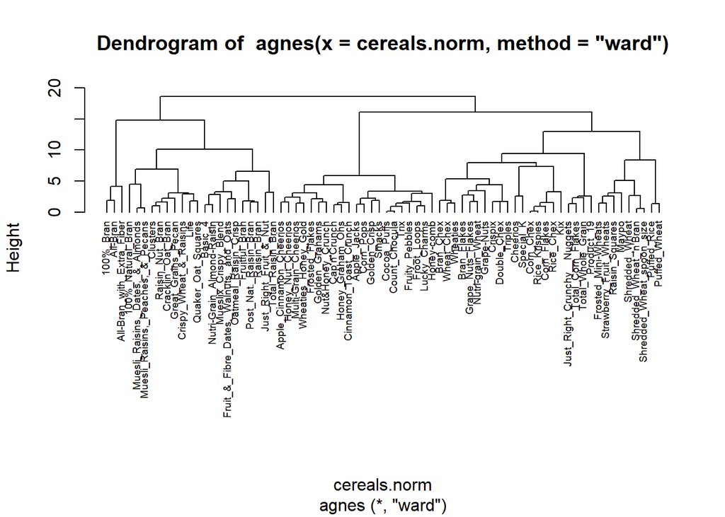

```r
#plotting the dendrogram
plot_w <- pltree(hc_w, cex = 0.6, hang = -1)
```

Let us apply now 2 techinques to figure out which values of k generate the best result.

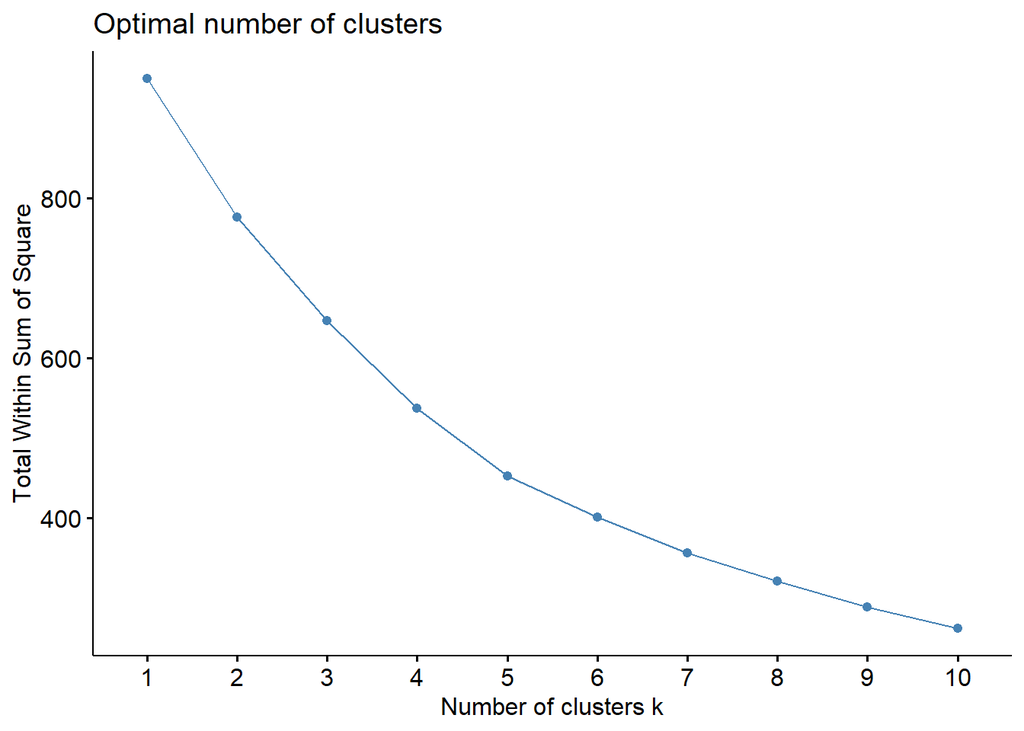

```r
#finding the best value of clusters k
fviz_nbclust(cereals.norm, FUN = hcut, method = "wss")
```

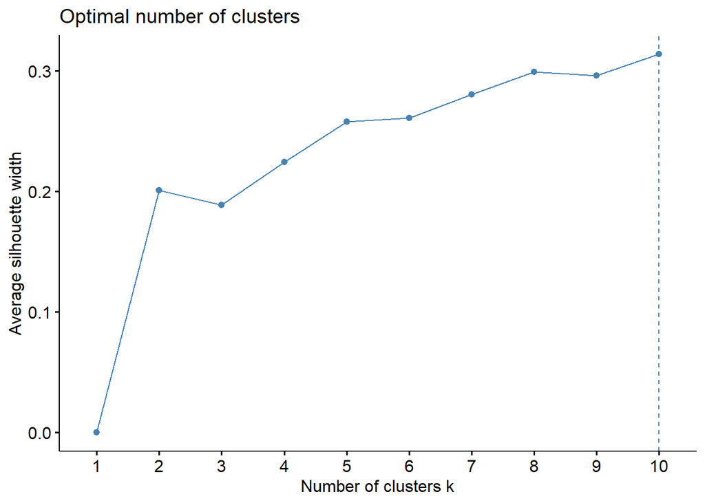

```r
fviz_nbclust(cereals.norm, FUN = hcut, method = "silhouette")
```

Looking at the Elbow chart it seems that a good level of clusters could be 5. From the Silhouette chart instead, we could reach the best result with 10 clusters. However we can see that with 5 clusters we could get a satisfying result. After this level, the model slighly increase its performance.

```r
#creating set of clusters
clusters5 <- cutree(hc_w, k=5)
clusters5
```

```
##  [1] 1 2 1 1 3 3 2 4 4 3 4 3 2 3 4 4 3 3 2 4 2 4 3 3 5 2 2 3 3 3 4 4 2 3 3 3 4 2
## [39] 4 2 3 5 2 2 2 3 3 2 4 2 2 4 5 5 2 2 2 5 4 4 5 5 5 3 4 5 4 2 4 4 3 4 4 3
```

```r
#plotting the clusters
clplot5 <- fviz_cluster(list(data = cereals.norm, cluster = clusters5))
```

# Analysis of Structure and Stability of the clusters

To check stability, we can divide the original dataset in 2 parts, partition A and partition B. Then, we see how similar the sets of clusters have been created for the 2 partitions and the original dataset. More precisely, we are going to allocate 50% of the data to partition A and the rest 50% to partition B, using “calories” variable.

```r
set.seed(123)

#partitioning data
datapart <- createDataPartition(cereals.norm[,"calories"], p=0.5, list=FALSE)
partitionA <- cereals.norm[datapart, ]
partitionB <- cereals.norm[-datapart, ]

#checking the results of the partition
summary(partitionA[,"calories"])
```

```
##     Min.  1st Qu.   Median     Mean  3rd Qu.     Max.
## -2.87378 -0.35412  0.14982  0.01362  0.14982  2.16555
```

```r
summary(partitionB[,"calories"])
```

```
##     Min.  1st Qu.   Median     Mean  3rd Qu.     Max.
## -2.87378 -0.35412  0.14982 -0.01362  0.14982  2.66948
```

As we can see, the data is equally distributed between the 2 partitions.

```r
set.seed(123)

#running AGNES to partition A and B
hc_w_A <- agnes(partitionA, method = "ward")
hc_w_B <- agnes(partitionB, method = "ward")

#comparing agglomerative coefficient and dendrogram
print(hc_w_A$ac)
```

```
## [1] 0.8271325
```

```r
print(hc_w_B$ac)
```

```
## [1] 0.8391847
```

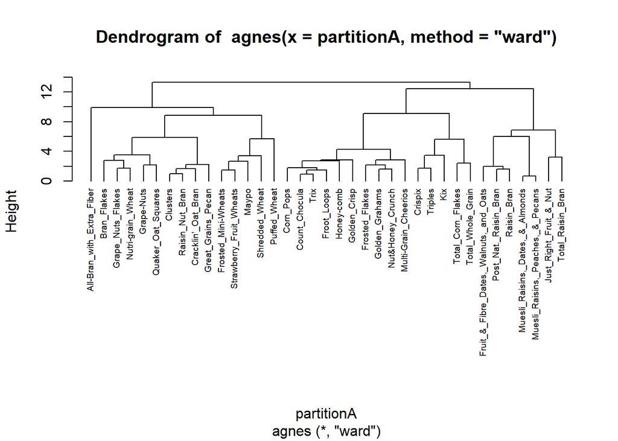

```r
plot_w_A <- pltree(hc_w_A, cex = 0.6, hang = -1)
```

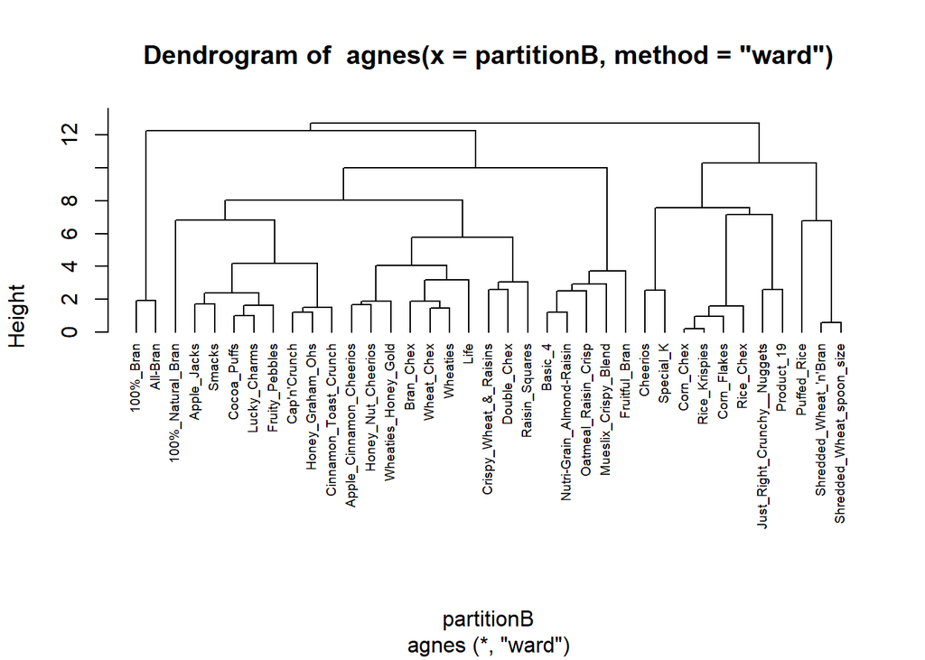

```r
plot_w_B <- pltree(hc_w_B, cex = 0.6, hang = -1)
```

We run the Ward’s method to partition A and B, as we previously did for the original dataset. The agglomerative coefficients are very similar: 82.71% for A and 83.92% for B.

# The elementary public schools case

The elementary public schools would like to choose a set of cereals to include in their daily cafeterias. Every day a different cereal is offered, but all cereals should support a healthy diet. For this goal, you are requested to find a cluster of “healthy cereals.”

In order to find the right cluster of cereals that schools are looking for we are going to analyze the median values of the variables for each cluster. The parameters to be considered to label cereals as healthy are proteins, sodium, fiber, sugars.

```r
#identifying cereals with clusters
cereals.clust <- cbind(clusters5, cereals.short)

#comparing metrics among clusters
median.table <- aggregate(cereals.short, list(clusters5), median)
median.table
```

```
##   Group.1 calories protein fat sodium fiber carbo sugars potass vitamins shelf
## 1       1       70       4   1    140    10  7.00    5.0  320.0       25     3
## 2       2      120       3   2    150     3 13.75    9.5  137.5       25     3
## 3       3      110       1   1    180     0 12.00   12.0   40.0       25     2
## 4       4      110       2   0    220     1 18.00    3.0   60.0       25     3
## 5       5       90       2   0      0     3 15.00    0.0   95.0        0     2
##   weight cups   rating
## 1  1.000 0.33 68.40297
## 2  1.125 0.67 38.54990
## 3  1.000 0.88 29.50954
## 4  1.000 1.00 46.65884
## 5  1.000 1.00 60.75611
```

According to our selection criteria, clusters 1 and 5 seem to be the best choices for providing a healthy food solution to children. However, we select cluster 1 because of the vitamins content that allows it to stand out from cluster 5. Note that selecting other variables would result in a different suggestion.